# HW-3 Penalized Regression Approaches

### Main purpose of this homework is to forecast the tomorrow’s hourly electricity consumption of Turkey. For this pupose the data from 1st of January, 2016 till the 1st of December, 2020 is used. Alternative strategies to model the consumption prediction are used to predict the tomorrow’s hourly electricity consumption, then these approaches are compared by using mean absolute percentage error (MAPE).

```r
#used libraries
library(data.table)
library(Matrix)
library(tidyverse)
library(dplyr)
library(glmnet)
```

## Task A

### In this task, 168 and 48 hours ago consumption values are used to predict next day’s consumption.

```r
#Reading data

#Data between 01/01/2016-31/10/2020 is used as training data
data_train = read.csv("C:/Users/OZGE/OneDrive - boun.edu.tr/doktora_ders/IE582/HW3/RealTimeConsumption-01012016-31102020.csv")

#Data between 01/11/2020-01/12/2020 is used as test data
data_test = read.csv("C:/Users/OZGE/OneDrive - boun.edu.tr/doktora_ders/IE582/HW3/RealTimeConsumption-01112020-01122020.csv")

#Since excel files are comma seperates files, commas are deleted to avoid confusion in consumption data.
data_train$Consumption..MWh. =  gsub(",", "",data_train$Consumption..MWh., fixed = TRUE)
data_train$Consumption..MWh. = as.numeric(data_train$Consumption..MWh.)

data_test$Consumption..MWh. =  gsub(",", "",data_test$Consumption..MWh., fixed = TRUE)
data_test$Consumption..MWh. = as.numeric(data_test$Consumption..MWh.)

data_test = data.frame(data_test)
data_train = data.frame(data_train)
```

```r
#Noisy data points are searched and discarded.
data_new = rbind(data_test,data_train)
#Search NA data
any(is.na(data_new))
#First dublicate variables are serached
double = duplicated(data_new)
j = 0
k = 0
dublicate_Data =c()
zero_Data = c()
for (i in 1:length(double)){
    if (double[i] == 'TRUE'){
        print(data_new[i,])
        dublicate_Data[j] = data_new[i,1]
        j = j+1
        }
}
#Then consumption values equal to zero variables are serached
for (i in 1:length(double)){
    if (data_new$Consumption..MWh.[i] == '0'){
        print(data_new[i,])
        zero_Data[k] = data_new[k,1]
        k+1
    }
}
```

FALSE

```
           Date  Hour Consumption..MWh.
2813 27.03.2016 04:00          24776.94
           Date  Hour Consumption..MWh.
2811 27.03.2016 02:00                 0
```

### There is no NA values in dataset and because of the daylight savings program Turkey 27.03.2016 has noisy variables.

```r
#deletion of 1 week from trainin data to discard noisy variables

data_train = data_train %>% filter(data_train$Date != '27.03.2016')
data_train = data_train %>% filter(data_train$Date != '26.03.2016')
data_train = data_train %>% filter(data_train$Date != '25.03.2016')
data_train = data_train %>% filter(data_train$Date != '24.03.2016')
data_train = data_train %>% filter(data_train$Date != '23.03.2016')
data_train = data_train %>% filter(data_train$Date != '22.03.2016')
data_train = data_train %>% filter(data_train$Date != '21.03.2016')
```

```r
#overall data is generated with rbind function
data = rbind(data_train, data_test)
len = nrow(data_train)
len_overall =nrow(data)
data = data.frame(data)
#Lag48 and Lag 168 is calculated to predict next day’s consumption
for (i in (len+1):len_overall){
    data_test$Lag48[i-len] = data$Consumption..MWh.[i-48]
    data_test$Lag168[i-len] = data$Consumption..MWh.[i-168]
}
diff =nrow(data_test)
#Absolute percentage error is calculated to predict the mape value
for (i in 1:diff){
    data_test$error_48[i] = abs((data_test$Consumption..MWh.[i]- data_test$Lag48[i])/ data_test$Consumption..MWh.[i])*100
    data_test$error_168[i] = abs((data_test$Consumption..MWh.[i]- data_test$Lag168[i])/ data_test$Consumption..MWh.[i])*100
}
#Hourly mape values are calculated
data_test$Hour = as.numeric(str_sub(data_test$Hour,1,2))
mape_Lag48_hour = c()
mape_Lag168_hour =c()
for (i in 0:23){
    new_data_a = data_test %>% filter(Hour == i)
    mape_Lag48_hour[(i+1)] = mean(new_data_a$error_48)
    mape_Lag168_hour[(i+1)] = mean(new_data_a$error_168)
}
```

```r
cat("\nSummary of mape values in part a for Lag48 approach")
summary(mape_Lag48_hour)
```

```
Summary of mape values in part a for Lag48 approach
```

```
   Min. 1st Qu.  Median    Mean 3rd Qu.    Max.
  4.673   4.920   5.861   8.060  11.721  14.147
```

```r
cat("\nSummary of mape values in part a for Lag168 approach")
summary(mape_Lag168_hour)
```

```
Summary of mape values in part a for Lag168 approach
```

```
   Min. 1st Qu.  Median    Mean 3rd Qu.    Max.
  2.466   2.619   2.830   3.449   4.164   5.441
```

### Next day electricity consumption is calculated with two different approaches. First, the data of 2 days ago same hour (Lag48), then the data of 7 days ago same hour (Lag168) is calculated. When MAPE values calculated for both approach, it is seen that, MAPE values of Lag168 approach is lower than Lag48 approach. So, it can be deduced that, electricity consumption data have week after week regularity.

## Task B

### In this task, data is presented as long format then linear regression model is used with two features (Lag48 and Lag168) and an intercept. Then mape values are calculated.

```r
#First 168 days are elimineted to be able to use the data 168 days ago
leng_train = nrow(data_train)
data_long = data_train[169:leng_train,]
new_length =nrow(data_long)
#Lag48 and Lag168 are calculated for training data
for (i in 1:new_length){
    data_long$Lag48[i] = data_train$Consumption..MWh.[i+168-48]
    data_long$Lag168[i] = data_train$Consumption..MWh.[i]
}
#Linear regression is applied with lm function
model = lm(Consumption..MWh.~ Lag48 + Lag168, data_long)

#Consumption data is predicted for test period
data_test$prediction = predict.lm(model,data_test)
test_long = nrow(data_test)

#Absolute percentage error is calculated to predict the mape value
for (i in 1:test_long){
    data_test$error[i] = abs((data_test$Consumption..MWh.[i]- data_test$prediction[i])/ data_test$Consumption..MWh.[i])*100
}
#Hourly mape values are calculated
mape_linear_hour = c()
for (i in 0:23){
    new_data_b = data_test %>% filter(Hour == i)
    mape_linear_hour[(i+1)] = mean(new_data_b$error)
}
model$coefficients
cat("\nSummary of mape values in part b")
summary(mape_linear_hour)
```

**(Intercept)**

1570.18882229884

**Lag48**

0.308641332690842

**Lag168**

0.643428639271023

```
Summary of mape values in part b
```

```
   Min. 1st Qu.  Median    Mean 3rd Qu.    Max.
  2.311   2.643   3.328   4.230   6.374   6.841
```

### Mean values of mape in this approach calculated in between the mape values of Lag48 approach and Lag168 aproach used in part a. Additionally, Lag168 has higher effect on predicting the next day electricity consumption according to coefficients of linear model.

## Task C

### In this task, 24 models are prepared for each hour to approach the same problem.

```r
task3_train = data_long
len_3 = nrow(task3_train)
#The values in hour column are determined as numeric values
task3_train$Hour = as.numeric(str_sub(task3_train$Hour,1,2))
data_test$Hour = as.numeric(str_sub(data_test$Hour,1,2))
```

```r
#Marix and vectors are defined.
model3 = c()
new_data = c()
new_data_2 = c()
prediction_new =c()
mape_3nd = c()
error =c()
pred_c = matrix(0,31,24)
error_c = matrix(0,31,24)
#For each hour the dataset is filtered than model is prepared with new filtered data
for (i in 0:23){
    new_data = task3_train %>% filter(Hour == i)
    new_data_2 = data_test %>% filter(Hour == i)
    model3= lm(Consumption..MWh.~ Lag48 + Lag168, new_data)
    prediction_new = predict.lm(model3,new_data_2)
    pred_num = length(prediction_new)
    cat("Coefficient of Hour=")
    hour = paste0(i,":00")
    cat(hour)
    cat('\n')
    print(model3$coefficients)
#prediction is calculated for test data and mape values are calculated.
    for (j in 1:pred_num){
        pred_c[j,(i+1)] =  prediction_new[j]
        error_c[j,(i+1)] = abs((new_data_2$Consumption..MWh.[j] - prediction_new[j])/ new_data_2$Consumption..MWh.[j])*100
    }
mape_3nd[(i+1)] = mean(error_c[,(i+1)])
}
cat("\n\nSummary of mape values in part c")
summary(mape_3nd)
```

```
Coefficient of Hour=0:00
 (Intercept)        Lag48       Lag168
2208.0929812    0.4871130    0.4420982
Coefficient of Hour=1:00
 (Intercept)        Lag48       Lag168
2136.7333692    0.4922278    0.4356324
Coefficient of Hour=2:00
 (Intercept)        Lag48       Lag168
2212.0288694    0.4972065    0.4252148
Coefficient of Hour=3:00
 (Intercept)        Lag48       Lag168
2242.9265625    0.4927577    0.4265157
Coefficient of Hour=4:00
 (Intercept)        Lag48       Lag168
2214.2704568    0.4747136    0.4446090
Coefficient of Hour=5:00
 (Intercept)        Lag48       Lag168
2235.2917414    0.4397479    0.4782117
Coefficient of Hour=6:00
 (Intercept)        Lag48       Lag168
2139.1104649    0.3757811    0.5459673
Coefficient of Hour=7:00
 (Intercept)        Lag48       Lag168
2318.7309566    0.2667591    0.6521278
Coefficient of Hour=8:00
 (Intercept)        Lag48       Lag168
3240.9400731    0.1741226    0.7249152
Coefficient of Hour=9:00
 (Intercept)        Lag48       Lag168
3602.5219746    0.1747390    0.7201044
Coefficient of Hour=10:00
 (Intercept)        Lag48       Lag168
3747.2157378    0.2065534    0.6863535
Coefficient of Hour=11:00
 (Intercept)        Lag48       Lag168
3965.9846694    0.2252224    0.6631854
Coefficient of Hour=12:00
 (Intercept)        Lag48       Lag168
3671.1148786    0.2801933    0.6129223
Coefficient of Hour=13:00
```

[output cut: 20 more lines]

```
Coefficient of Hour=20:00
 (Intercept)        Lag48       Lag168
2797.0300974    0.4075812    0.5144407
Coefficient of Hour=21:00
 (Intercept)        Lag48       Lag168
2674.3575097    0.4285403    0.4955428
Coefficient of Hour=22:00
 (Intercept)        Lag48       Lag168
2838.7809692    0.4420128    0.4757150
Coefficient of Hour=23:00
 (Intercept)        Lag48       Lag168
2555.8358497    0.4504693    0.4722353


Summary of mape values in part c
```

```
   Min. 1st Qu.  Median    Mean 3rd Qu.    Max.
  3.148   3.199   3.589   4.359   5.638   6.685
```

### The Mean value of mape calculations in this part is a little bit higher than the part b, however the difference in between the min value and maximum value of mean values is lower than the part b.

## Task D

### Data is presented as wide format and prediction model is built by 48 features (hourly consumption from two days ago and last week’s hourly consumption) and penalized regression approaches with a 10-fold cross-validation.

```r
#training data conversion
data_d = data_long
data_d$Date <- as.Date(data_d$Date,"%d.%m.%Y")
Lag_168_hour = dcast(data_d, Date ~ Hour, sum, value.var = "Lag168" )
colnames(Lag_168_hour) <- c("Date",paste0("Lag168_hour_", 0:23))
Lag_48_hour = dcast(data_d, Date ~ Hour, sum, value.var = "Lag48" )
colnames(Lag_48_hour) <- c("Date",paste0("Lag48_hour_", 0:23))
Cons_hour = dcast(data_d, Date ~ Hour, sum, value.var = "Consumption..MWh." )
colnames(Cons_hour) <- c("Date",paste0("Consumption_hour_", 0:23))
day_hour_data_train = cbind(Lag_168_hour, Lag_48_hour[,2:25], Cons_hour[,2:25])
#test data conversion
data_test_d = data_test
data_test_d$Date <- as.Date(data_test_d$Date,"%d.%m.%Y")
Lag_168_hour_2 = dcast(data_test_d, Date ~ Hour, sum, value.var = "Lag168" )
colnames(Lag_168_hour_2) <- c("Date",paste0("Lag168_hour_", 0:23))
Lag_48_hour_2 = dcast(data_test_d, Date ~ Hour, sum, value.var = "Lag48" )
colnames(Lag_48_hour_2) <- c("Date",paste0("Lag48_hour_", 0:23))
Cons_hour_2 = dcast(data_test_d, Date ~ Hour, sum, value.var = "Consumption..MWh." )
colnames(Cons_hour_2) <- c("Date",paste0("Consumption_hour_", 0:23))
day_hour_data_test = cbind(Lag_168_hour_2, Lag_48_hour_2[,2:25], Cons_hour_2[,2:25])
#combining datas
day_hour_data = rbind(day_hour_data_train, day_hour_data_test)
```

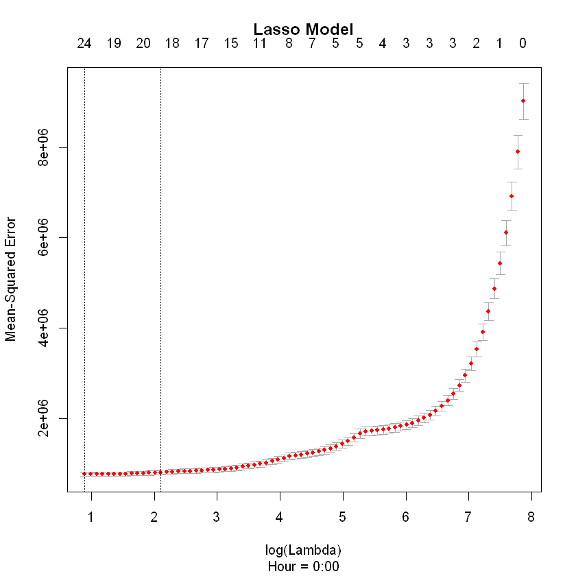

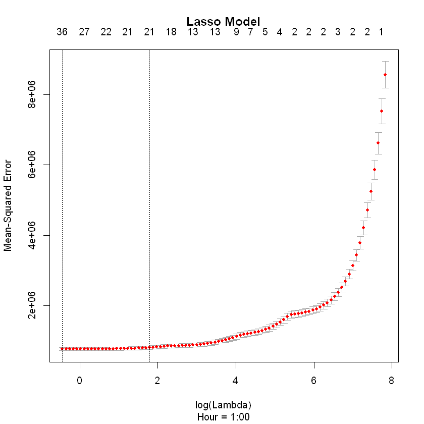

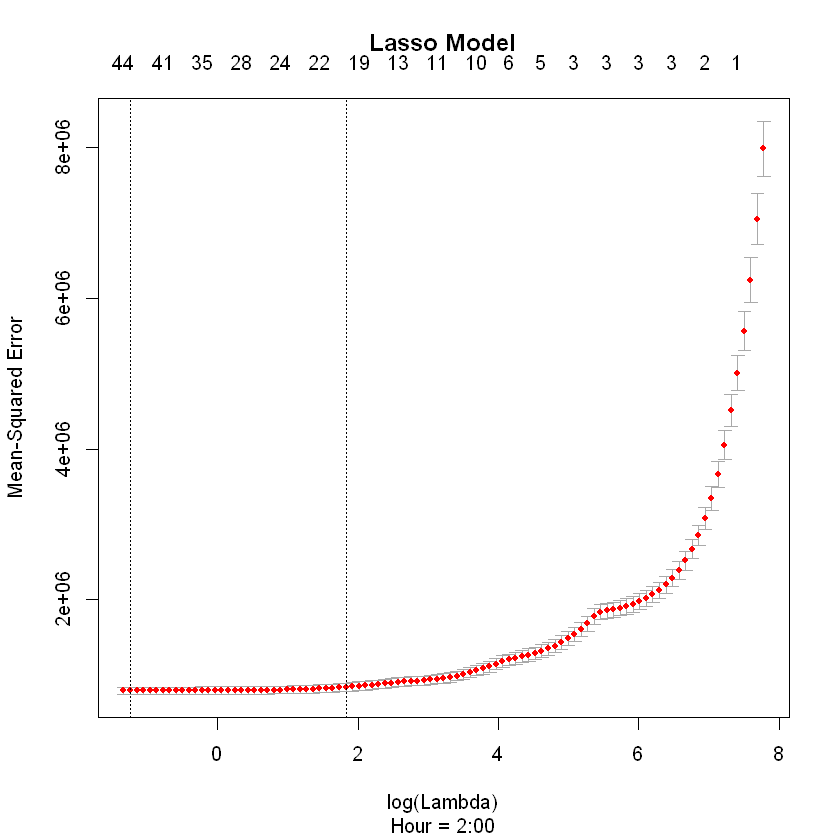

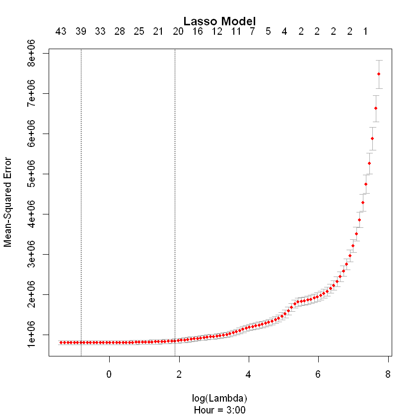

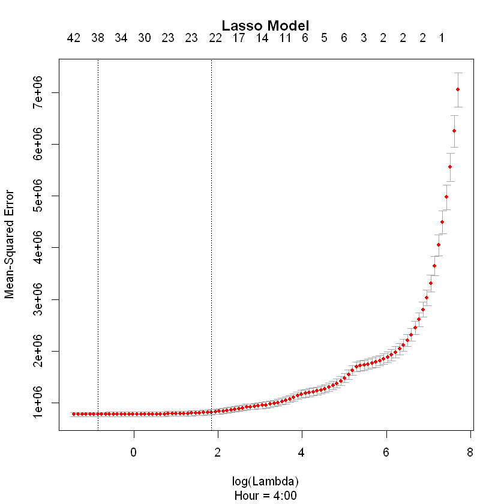

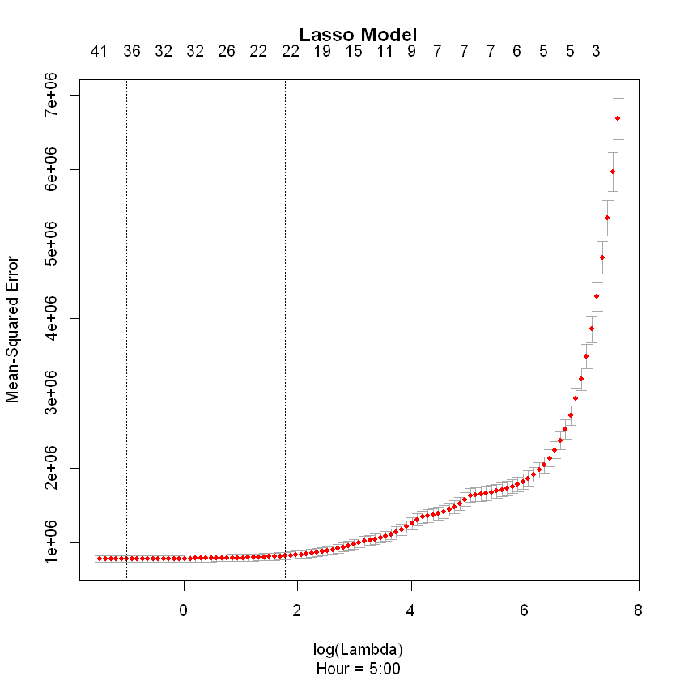

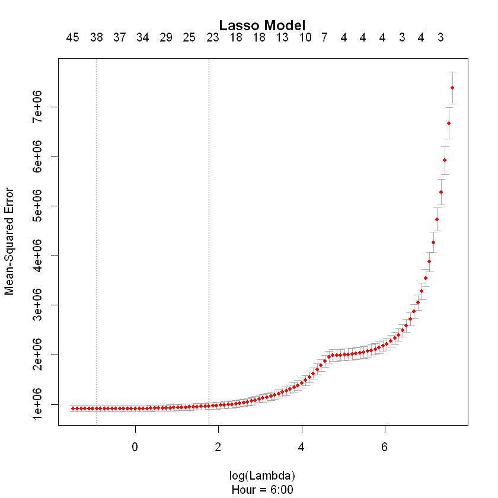

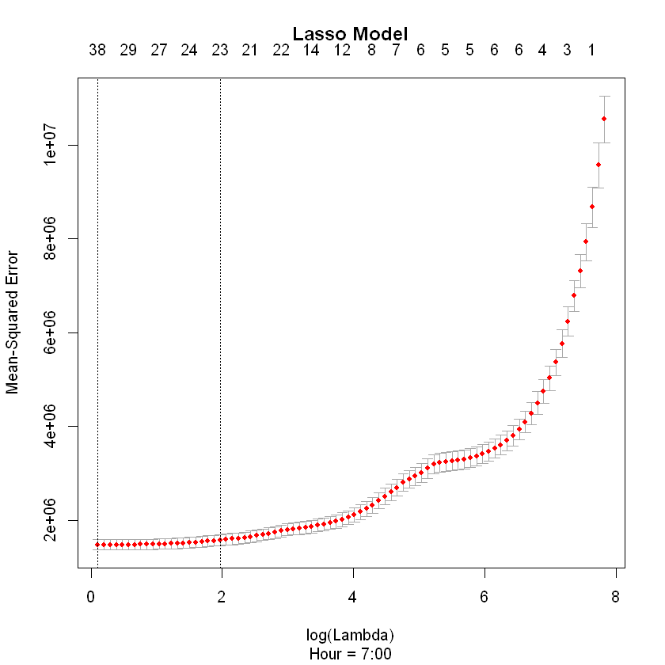

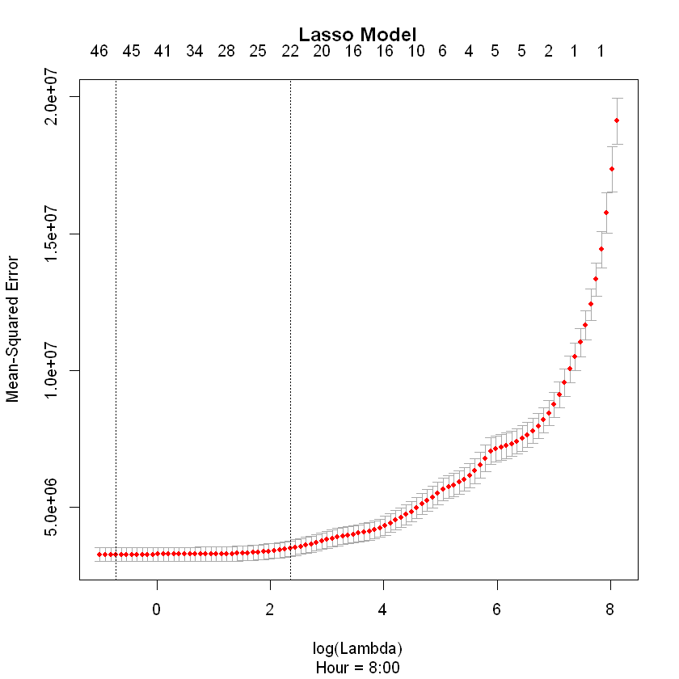

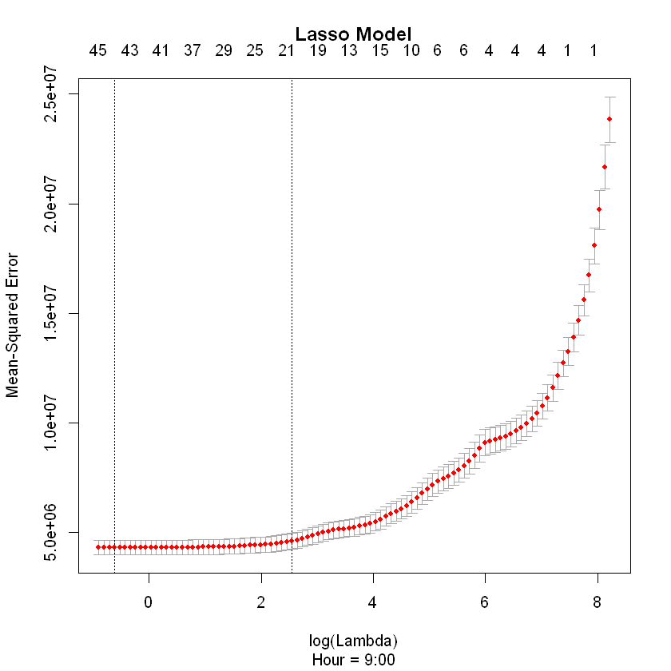

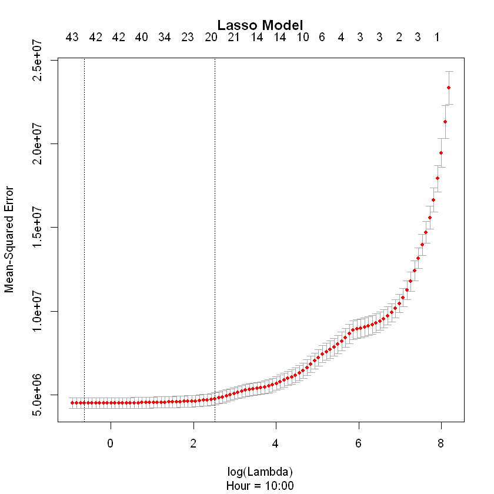

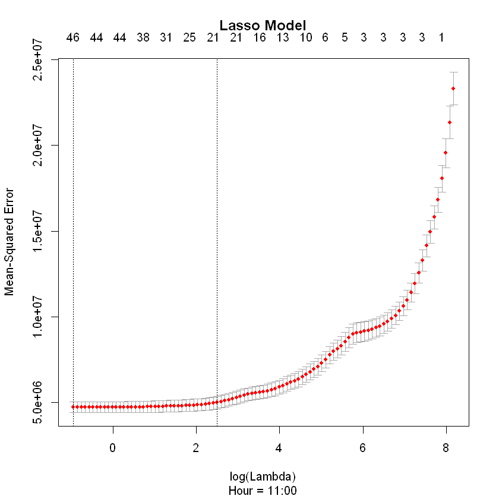

[12 more figures not shown]

```r
#Matrix and vectors are defined
x_train = day_hour_data_train[,2:49]
x_test = day_hour_data_test[,2:49]
x_train =  as.matrix(x_train)
x_test =  as.matrix(x_test)
lasso = c()
pred = matrix(0,31,24)
error = matrix(0,31,24)
mape_d = c()
lasso_coef = c()
lasso_model=c()
model_24hour = c()
A=c()
coeff_lasso = c()
#coeff_lasso = matrix(0,49,24)
for (i in 1:24){
    set.seed(621)
    #consumtion data for each hour is equalized to y for training data and y_test for test data
    y = day_hour_data_train[,49+i]
    y_test = day_hour_data_test[,49+i]
    y = as.matrix(y)
    #glmnet function is used to obtain model
    lasso_model = cv.glmnet(x_train , y  , type.measure="mse", family="gaussian", nfolds = 10)
    hour = paste0(i-1,":00")
    plot(lasso_model, sub=substitute(paste('Hour =', hour)))
    title("Lasso Model",adj = 0.5, line = 2)
    #lambda is selected as lambda.1se
    lambdax = lasso_model$lambda.1se
    best_lasso = glmnet(x_train , y  , alpha =1, lambda = lambdax)
    #prediction is made for test data and mape values are calculated
    lasso = predict(best_lasso,  s=lambdax, newx = x_test)
    len_x_test =nrow(x_test)
    lasso_coef$lambda_1se[i] = lasso_model$lambda.1se
    lasso_coef$lambda_min[i] = lasso_model$lambda.min
    if (i==1){
        coeff_lasso = coefficients(lasso_model)
    }
    coeff_lasso = cbind(coeff_lasso, coefficients(lasso_model))
    #A = coefficients(lasso_model)
    #coeff_lasso[,i] = A[,1]
    for (j in 1:len_x_test){
        pred[j,i] = lasso[j,1]
        error[j,i] = abs((y_test[j]-pred[j,i])/y_test[j])*100
    }
    mape_d[i] = mean(error[,i])
}
```

### When we look at the mean-squared error vs log(lambda) graph, it can be deduced that in lower lambda values, the variance is much lower than the higher lambda values. For this reason, it is prefered to use lambda.min and lambda.1se to minimize the mean squared error and variance. When we look at the 24 graph for each hour, it can be concluded that they have similar profile.

```r
#Coefficients of lasso Model
print(coeff_lasso)
```

```
49 x 25 sparse Matrix of class "dgCMatrix"
```

```
   [[ suppressing 25 column names '1', '1', '1' ... ]]
```

```
(Intercept)    742.60226483 742.60226483  1.074311e+03  1.484838e+03
Lag168_hour_0    0.07364237   0.07364237  .             .
Lag168_hour_1    .            .           7.155025e-02  .
Lag168_hour_2    .            .           .             .
Lag168_hour_3    .            .           .             .
Lag168_hour_4    .            .           5.407961e-03  9.649017e-02
Lag168_hour_5    .            .           .             .
Lag168_hour_6    0.11335704   0.11335704  9.077042e-02  .
Lag168_hour_7    0.20398258   0.20398258  1.935790e-01  2.237717e-01
Lag168_hour_8    .            .           1.981765e-02  6.910793e-02
Lag168_hour_9    .            .           .             .
Lag168_hour_10   .            .           .             .
Lag168_hour_11   0.07248630   0.07248630  3.316123e-02  4.455208e-05
Lag168_hour_12   0.01461945   0.01461945  .             .
Lag168_hour_13   .            .           .             .
Lag168_hour_14   .            .           5.994250e-02  6.064108e-02
Lag168_hour_15   .            .           .             .
Lag168_hour_16   .            .           .             .
Lag168_hour_17   .            .           .             .
Lag168_hour_18   .            .          -2.069684e-03 -3.931450e-03
Lag168_hour_19  -0.13834816  -0.13834816 -1.263110e-01 -9.602922e-02
Lag168_hour_20  -0.20089785  -0.20089785 -2.656436e-01 -2.613775e-01
Lag168_hour_21   .            .           .             .
Lag168_hour_22  -0.03663771  -0.03663771  .            -2.057989e-02
Lag168_hour_23   .            .           .             .
Lag48_hour_0    -0.09391613  -0.09391613 -2.149429e-01 -4.310858e-01
Lag48_hour_1    -0.04589697  -0.04589697  .             .
Lag48_hour_2     .            .           .             .
Lag48_hour_3     .            .           1.085939e-04  1.740087e-01
Lag48_hour_4     .            .           1.167739e-01  2.211423e-01
Lag48_hour_5     .            .           .             .
Lag48_hour_6     .            .           .             .
Lag48_hour_7     0.12801442   0.12801442  1.078931e-01  5.215101e-02
Lag48_hour_8     .            .           .             .
Lag48_hour_9    -0.52713761  -0.52713761 -4.569298e-01 -4.320809e-01
Lag48_hour_10   -0.03351962  -0.03351962 -1.771207e-02 -4.145032e-02
Lag48_hour_11    .            .          -1.581293e-01 -1.191464e-01
Lag48_hour_12    .            .           .             .
Lag48_hour_13    0.11793205   0.11793205  1.511711e-01  1.193349e-01
Lag48_hour_14    .            .           .             .
```

[output cut: 294 more lines]

```
Lag48_hour_9   -5.493952e-01
Lag48_hour_10   .
Lag48_hour_11   .
Lag48_hour_12   .
Lag48_hour_13   2.803860e-01
Lag48_hour_14  -1.196123e-01
Lag48_hour_15   .
Lag48_hour_16  -2.252845e-03
Lag48_hour_17   .
Lag48_hour_18   .
Lag48_hour_19   .
Lag48_hour_20   .
Lag48_hour_21   2.867324e-01
Lag48_hour_22   .
Lag48_hour_23   9.536810e-01
```

```r
#writing coefficients of lasso
#deleting intercept
coeff_l = coeff_lasso[2:49,]
for (i in 1:24){
    cat("Coefficient of Lag168_hour_")
    cat(i-1)
    cat('\n')
    print(summary(coeff_l[i,]))
    }
for (j in 25:48){
    cat("Coefficient of Lag48_hour_")
    cat(j-25)
    cat('\n')
    print(summary(coeff_l[j,]))
    }
```

```
Coefficient of Lag168_hour_0
     Min.   1st Qu.    Median      Mean   3rd Qu.      Max.
-0.096074  0.000000  0.000000  0.001887  0.000000  0.073642
Coefficient of Lag168_hour_1
    Min.  1st Qu.   Median     Mean  3rd Qu.     Max.
0.000000 0.000000 0.000000 0.002862 0.000000 0.071550
Coefficient of Lag168_hour_2
     Min.   1st Qu.    Median      Mean   3rd Qu.      Max.
-0.211589  0.000000  0.000000 -0.008506  0.000000  0.000000
Coefficient of Lag168_hour_3
   Min. 1st Qu.  Median    Mean 3rd Qu.    Max.
      0       0       0       0       0       0
Coefficient of Lag168_hour_4
    Min.  1st Qu.   Median     Mean  3rd Qu.     Max.
-0.27153 -0.14714  0.00000 -0.05905  0.00000  0.09649
Coefficient of Lag168_hour_5
   Min. 1st Qu.  Median    Mean 3rd Qu.    Max.
-1.1271 -0.9143 -0.6399 -0.5539  0.0000  0.0218
Coefficient of Lag168_hour_6
   Min. 1st Qu.  Median    Mean 3rd Qu.    Max.
0.00000 0.00000 0.00000 0.01601 0.00000 0.11336
Coefficient of Lag168_hour_7
   Min. 1st Qu.  Median    Mean 3rd Qu.    Max.
 0.1936  0.2511  0.3709  0.3892  0.4908  0.9215
Coefficient of Lag168_hour_8
   Min. 1st Qu.  Median    Mean 3rd Qu.    Max.
0.00000 0.07319 0.19402 0.28445 0.49480 0.90393
Coefficient of Lag168_hour_9
   Min. 1st Qu.  Median    Mean 3rd Qu.    Max.
0.00000 0.00000 0.00000 0.03739 0.00000 0.33967
Coefficient of Lag168_hour_10
   Min. 1st Qu.  Median    Mean 3rd Qu.    Max.
0.00000 0.00000 0.00000 0.00897 0.00000 0.10969
Coefficient of Lag168_hour_11
      Min.    1st Qu.     Median       Mean    3rd Qu.       Max.
-1.348e-01 -4.560e-06  0.000e+00 -9.802e-03  0.000e+00  7.249e-02
Coefficient of Lag168_hour_12
    Min.  1st Qu.   Median     Mean  3rd Qu.     Max.
-0.19520 -0.02487  0.00000 -0.02658  0.00000  0.05751
Coefficient of Lag168_hour_13
```

[output cut: 89 more lines]

```
Coefficient of Lag48_hour_19
    Min.  1st Qu.   Median     Mean  3rd Qu.     Max.
-0.01079  0.00000  0.00000  0.01768  0.00000  0.45277
Coefficient of Lag48_hour_20
   Min. 1st Qu.  Median    Mean 3rd Qu.    Max.
0.00000 0.00000 0.02326 0.09228 0.13178 0.52556
Coefficient of Lag48_hour_21
   Min. 1st Qu.  Median    Mean 3rd Qu.    Max.
0.00000 0.00000 0.00000 0.08098 0.09656 0.64741
Coefficient of Lag48_hour_22
   Min. 1st Qu.  Median    Mean 3rd Qu.    Max.
 0.0000  0.0000  0.0000  0.1129  0.2532  0.4084
Coefficient of Lag48_hour_23
   Min. 1st Qu.  Median    Mean 3rd Qu.    Max.
 0.6725  0.8204  0.9752  0.9850  1.1737  1.3298
```

### Coefficients that are not used in 24 model are Lag168_hour_3 and Lag48_hour_12. Less effective features (mean values in summary table < 0.01) are determined as: Lag168_hour_10, Lag168_hour_11, Lag168_hour_18, Lag168_hour_21, Lag48_hour_3, Lag48_hour_15, Lag48_hour_16, and Lag48_hour_17. Highly effective features (mean values in summary table > 0.50) are determined as Lag48_hour_23, Lag48_hour_9, Lag168_hour_5, Lag48_hour_5, Lag48_hour_13.

```r
#Summary of mape values
cat("Summary of mape values in part d\n")
summary(mape_d)
```

```
Summary of mape values in part d
```

```
   Min. 1st Qu.  Median    Mean 3rd Qu.    Max.
  1.362   1.500   1.691   2.463   3.711   4.751
```

### This method has the lowest mean of mape values among the methods used to predict the electricity consumption.

## Part F

### The results are compared by drawing a boxplot of MAPE values for each approach on same plot

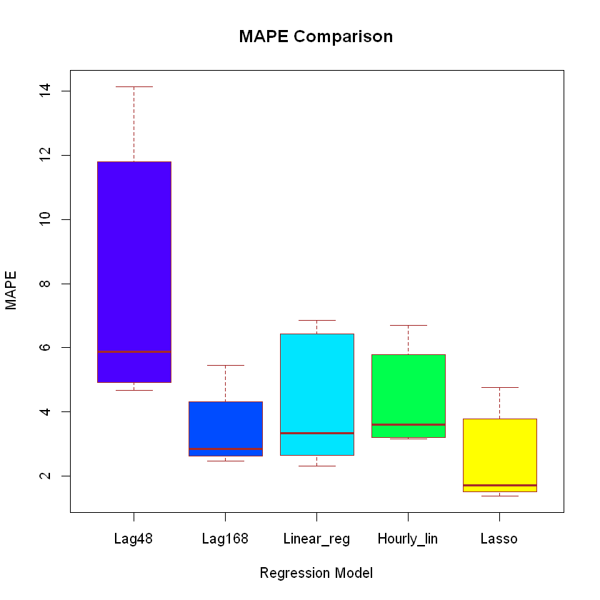

```r
Lag48 = mape_Lag48_hour
Lag168 = mape_Lag168_hour
Linear_reg = mape_linear_hour
Hourly_lin = mape_3nd
Lasso = mape_d
results = cbind(Lag48, Lag168, Linear_reg, Hourly_lin, Lasso)
results = data.frame(results)
boxplot(results,main="MAPE Comparison",
xlab="Regression Model",
ylab="MAPE",
col=topo.colors(5),
border="brown"
)
```

### Mape values obtained by the model with Lasso approach for each hour are the lowest mape values calculated in this homework. Also, the variance of mape values in this approach is small. For this reason, it can be concluded that the Lasso approach is best way to predict the electiricity consumption for the next day beyond the methods used in this homework. Second best method is the method in which 168 hours ago consumption values used as our naïve approaches to predict next day’s consumption. Mean value of mape calculations of this approach is also lower and variance of mape values is the smallest among the other methods. The mape values calculated by linear regression method in part b has third lowest mean value, however its variance is higher than the hourly linear regression method. The worst method is the model in which 48 hours ago consumption values used as our naïve approaches to predict next day’s consumption, because its mean value of mape calculations are highest and its variance is very high.